# MiCA workshop ASV inference

## dada2 data processing

To process the raw sequence data we use dada2 at MiCA. DADA2 infers exact amplified sequence variants (ASV). It is possible to get single nucleotide resolution allowing for the highest possible phylogenetic resolution with the current technologies.

For quality assurance we include possitive and negative control samples in each pooled amplicon libaries. The posititve control consists of a MOCK community sample for which the composition is known. In this case the sample was composed of DNA from 55 diffent bacterial strains. More details about the mock samples can be found at https://f1000research.com/articles/5-1791/v1 As a show case we will process one of these mock libraries

First we install and load the necessary packages.

```r
# load libraries
.cran_packages <- c("ggplot2", "reshape2")
.bioc_packages <- c("dada2", "phyloseq","ShortRead","decontam")
.inst <- .cran_packages %in% installed.packages()
if(any(!.inst)) {
   install.packages(.cran_packages[!.inst])
}
.inst <- .bioc_packages %in% installed.packages()
if(any(!.inst)) {
   source("http://bioconductor.org/biocLite.R")
   biocLite(.bioc_packages[!.inst], ask = F)
}
# Load packages into session, and print package version
sapply(c(.cran_packages, .bioc_packages), require, character.only = TRUE, quietly = T)
```

```
##   ggplot2  reshape2     dada2  phyloseq ShortRead  decontam
##      TRUE      TRUE      TRUE      TRUE      TRUE      TRUE
```

To start the worksop we process the sequence data of one of the postive controls. First we download the and asses the quality of the run.

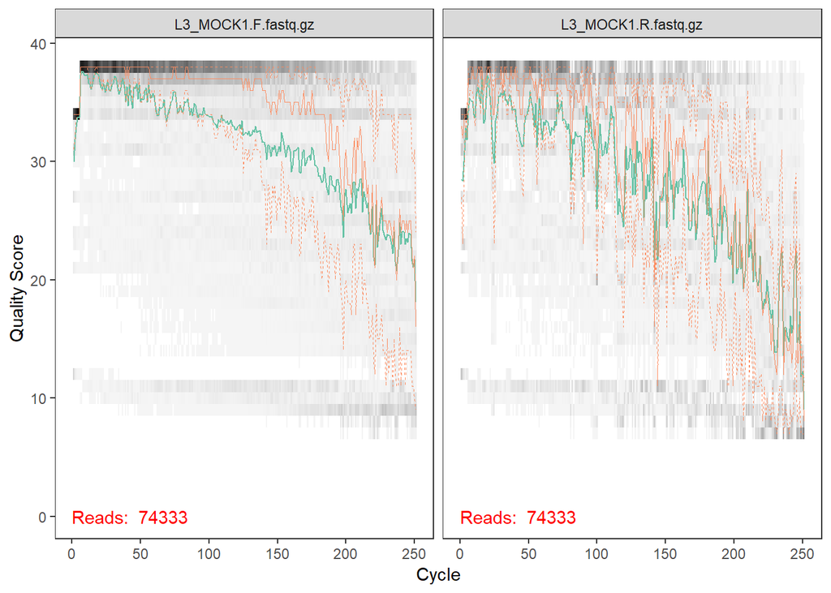

```r
FQF <- "./Raw_data/L3_MOCK1.F.fastq.gz"
FQR <- "./Raw_data/L3_MOCK1.R.fastq.gz"

#visualize the quality of the data
plotQualityProfile(c(FQF,FQR))
```

So we can see the sample has 74333 reads.

A bit more intuative is to look at the expected error rather than looking at the mean quality distribution.

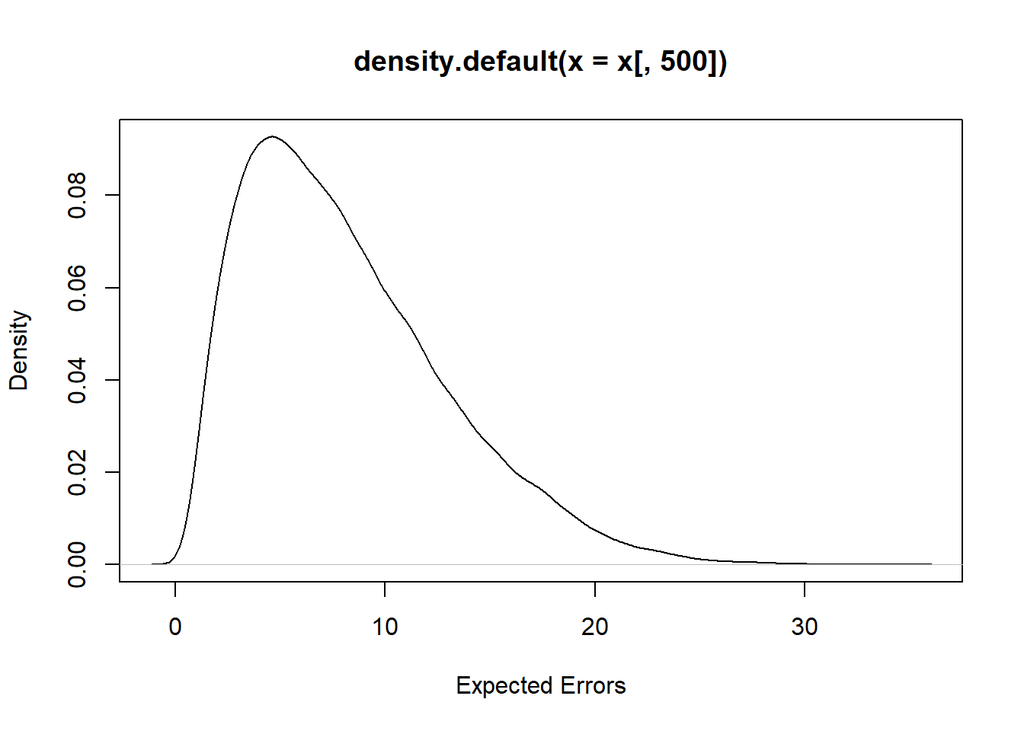

```r
x <- cbind(as.matrix(PhredQuality(quality(readFastq(FQF)))),as.matrix(PhredQuality(quality(readFastq(FQR)))))
#calculate cumalative error rates
x <- t(apply(10^(-x/10), 1, cumsum))
# Error rate statistics
plot(density(x[,500]), xlab="Expected Errors")
```

```r
summary(x[,500])
```

```
##    Min. 1st Qu.  Median    Mean 3rd Qu.    Max.
##  0.2137  4.4166  7.2537  8.1537 11.0237 34.6272
```

```r
drrut <- derepFastq(FQF)
drrut
```

```
## derep-class: R object describing dereplicated sequencing reads
## $uniques: 74333 reads in 59118 unique sequences
##   Sequence lengths: min=251, median=251, max=251
## $quals: Quality matrix dimension:  59118 251
##   Consensus quality scores: min=7, median=35, max=38
## $map: Map from reads to unique sequences:  53754 5696 9443 25284 17014 ...
```

```r
sum(table(drrut$map)==1)
```

```
## [1] 56871
```

```r
drfut <- derepFastq(FQR)
drfut
```

```
## derep-class: R object describing dereplicated sequencing reads
## $uniques: 74333 reads in 68629 unique sequences
##   Sequence lengths: min=251, median=251, max=251
## $quals: Quality matrix dimension:  68629 251
##   Consensus quality scores: min=7, median=31, max=38
## $map: Map from reads to unique sequences:  38277 22800 68505 24182 30459
## ...
```

```r
sum(table(drfut$map)==1)
```

```
## [1] 67474
```

This shows that on average a read has 8 expected errors. This results in many unique sequences. From the reverse read 67474 out of 74333 (90%) are unique! This is an issue for amplicon inference because dada2 can only infer ASVs from duplicated reads.

Luckily we can remove some of the poor quality regions of the reads to eleviate this issue some what. The length of the V3V4 amplicons are between 400 and 430 bases, which means there is a 100 to base pair overlap between the forward and reverse read. In order to merge the ends we need at least a 20 bp overlap, so we can trim a total of 50 poor quality bases. We found that trimming 10 bases from the forward read and 40 from the reverse is optimal, and we trim down the forward and reverse reads to 240 and 210 respectively.

Furthermore DADA2 cannot handle sequences containing ambigious nucleotides and therefore these are filtered out (maxN=0). In contrast to the dada2 tutorial we do not filter on expected errors. We have found that sequence quality differs between amplicons and therefore quality filtering will skew the final composition.

```r
# filtered output
FQFF <- "./Output/FQFF.gz"
FQRF <- "./Output/FQRF.gz"

out <- filterAndTrim(FQF, FQFF, FQR, FQRF ,maxN=0, truncQ=0, rm.phix=T, compress=TRUE, multithread=F, truncLen=c(240,210))
out
```

```
##                     reads.in reads.out
## L3_MOCK1.F.fastq.gz    74333     74329
```

There were no problems with filtering and only four sequences were removed.

These sequences were actually Illumina control spike in phiX sequences which are incorrectly assigned to the sample during demultiplexing of the libraries. This issue is known as cross talk. THough in general the rate of cross talk is low, this specifically impacts presence/absence type of analysis.

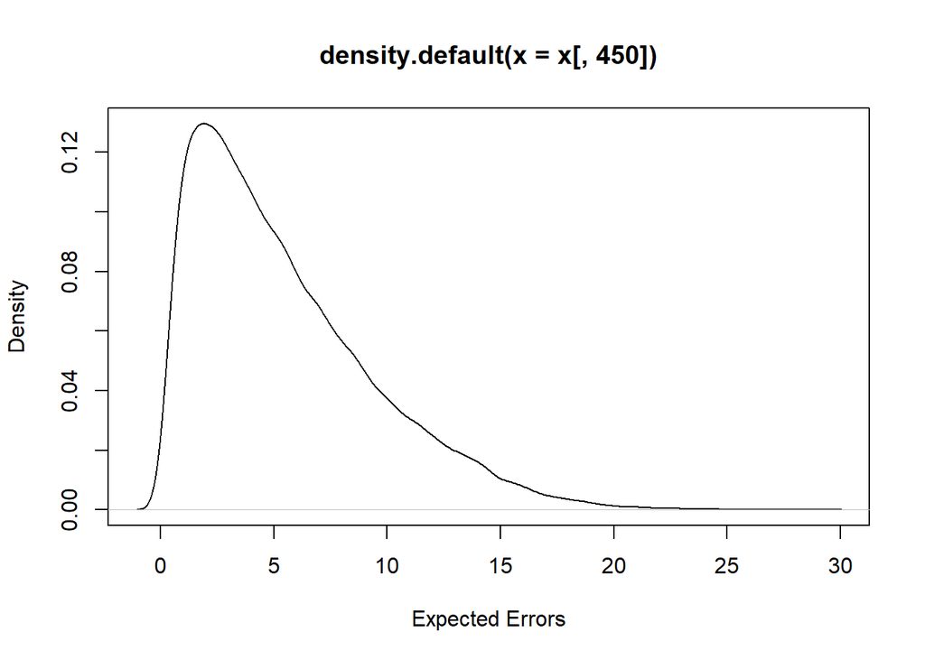

```r
x <- cbind(as.matrix(PhredQuality(quality(readFastq(FQFF)))),as.matrix(PhredQuality(quality(readFastq(FQRF)))))
#calculate cumalative error rates
x <- t(apply(10^(-x/10), 1, cumsum))
# Error rate statistics
plot(density(x[,450]), xlab="Expected Errors")
```

```r
summary(x[,450])
```

```
##     Min.  1st Qu.   Median     Mean  3rd Qu.     Max.
##  0.08024  2.35631  4.54074  5.48335  7.72546 28.87945
```

```r
drf <- derepFastq(FQFF)
drf
```

```
## derep-class: R object describing dereplicated sequencing reads
## $uniques: 74329 reads in 55651 unique sequences
##   Sequence lengths: min=240, median=240, max=240
## $quals: Quality matrix dimension:  55651 240
##   Consensus quality scores: min=7, median=35, max=38
## $map: Map from reads to unique sequences:  50528 5875 9479 24068 16529 ...
```

```r
sum(table(drf$map)==1)
```

```
## [1] 53124
```

```r
drr <- derepFastq(FQRF)
drr
```

```
## derep-class: R object describing dereplicated sequencing reads
## $uniques: 74329 reads in 55205 unique sequences
##   Sequence lengths: min=210, median=210, max=210
## $quals: Quality matrix dimension:  55205 210
##   Consensus quality scores: min=7, median=33, max=38
## $map: Map from reads to unique sequences:  31496 173 55083 21297 25824 ...
```

```r
sum(table(drr$map)==1)
```

```
## [1] 52819
```

This reduced the mean expected error rate to 5.5 but more importanty the number of singleton reads dropped to 53124 (71 %)

## Calculation of the batch specific error

The second step in the process is the estimation of the batch specific error rates. Use of the quality score to test the validity of a sequence is what sets dada2 appart from the other platforms.

Error estimation is somewhat computional demanding and therefore precalculate error rates for this particular sequence run is supplies. Otherwise error rates can be obtained using learnErrors (eg errF <- learnErrors(FQFF, multithread=F)). The following plots can be used to asses the error models and should show linear decrease in substition rates over quality scores.

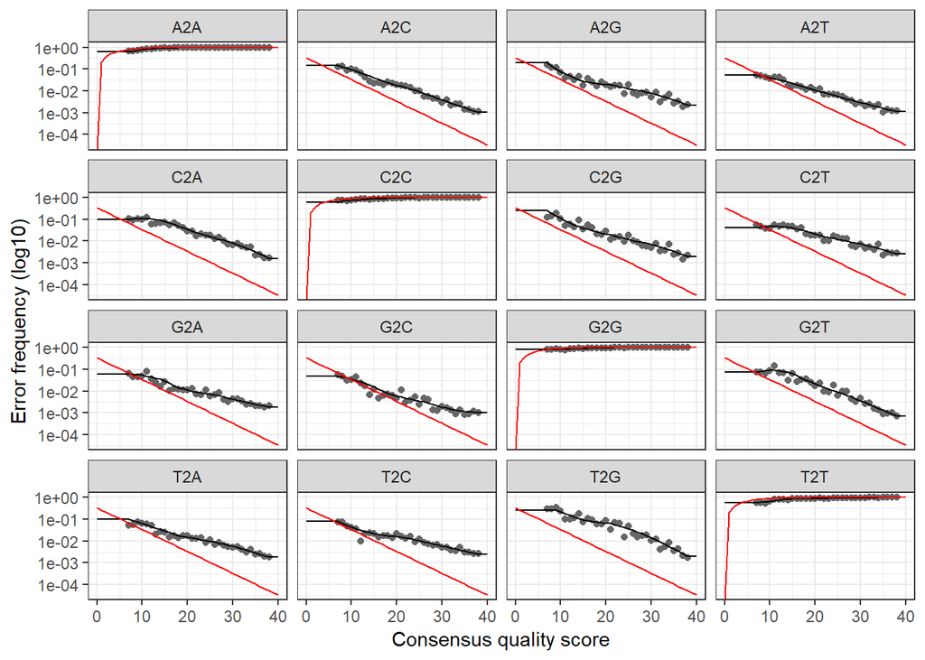

```r
errF <- readRDS("./Raw_data/L3_dada2.errF.RDS")
plotErrors(errF, nominalQ=TRUE)
```

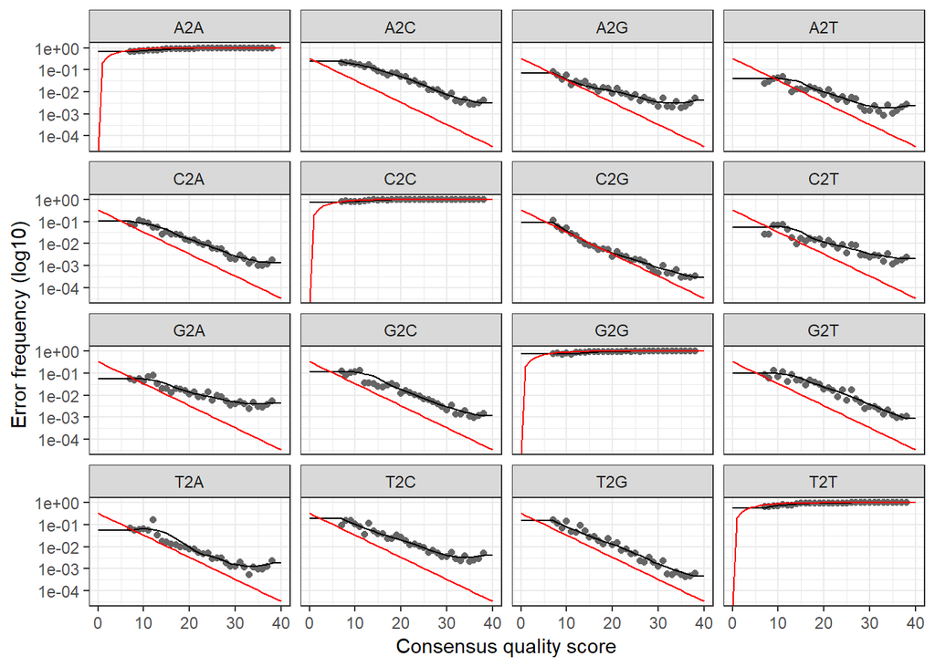

```r
errR <- readRDS("./Raw_data/L3_dada2.errR.RDS")
plotErrors(errR, nominalQ=TRUE)
```

Points show the quality score dependent substition rates while the red shows the calculated rates. Results show that overall substitution rates are even higher than what can be expected from the quality score but in general follow the trend.

## ASV Inference

The third step in the dada2 workflow is the inference of the ASVs.

```r
asv.f <- dada(derep = drf, err = errF)
```

```
## Sample 1 - 74329 reads in 55651 unique sequences.
```

```r
asv.f
```

```
## dada-class: object describing DADA2 denoising results
## 216 sequence variants were inferred from 55651 input unique sequences.
## Key parameters: OMEGA_A = 1e-40, OMEGA_C = 1e-40, BAND_SIZE = 16
```

```r
asv.r <- dada(derep = drr, err = errR)
```

```
## Sample 1 - 74329 reads in 55205 unique sequences.
```

```r
asv.r
```

```
## dada-class: object describing DADA2 denoising results
## 133 sequence variants were inferred from 55205 input unique sequences.
## Key parameters: OMEGA_A = 1e-40, OMEGA_C = 1e-40, BAND_SIZE = 16
```

```r
sum(is.na(asv.f$map[drr$map]) | is.na(asv.r$map[drf$map]))
```

```
## [1] 8005
```

```r
saveRDS(asv.f,"./Output/asvf.RDS")
saveRDS(asv.r,"./Output/asvr.RDS")
```

dada2 inferred 216 amplicon sequences from the forward reads and 133 from the reverse reads. Furthermore dada2 did not find an suitable ASV representative for 8005 (10%) of the reads.

## ASV pair Merging

To get a single represensative sequence ASV corresponding to each read pair are merged. Only those pairs that can be joined with at least a 20 bases overlap and without any mismatches are accepted.

```r
asv.m <- mergePairs(dadaF = asv.f, derepF = drf, dadaR = asv.r, derepR = drr, returnRejects = T)
```

```
## Duplicate sequences in merged output.
```

```r
head(asv.m)
```

```
##                                                                                                                                                                                                                                                                                                          …
## 1 TGAGGAATATTGGTCAATGGACGCAAGTCTGAACCAGCCATGCCGCGTGCAGGATGACGG…
## 2                     TGGGGAATATTGCACAATGGGGGAAACCCTGATGCAGCGACGCCGCGTGGAGGAAGAAGG…
## 3               TCGAGAATCATTCACAATGGGGGAAACCCTGATGGTGCGACGCCGCGTGGGGGAATGAAG…
## 4 TGAGGAATATTGGTCAATGGCCGAGAGGCTGAACCAGCCAAGTCGCGTGAGGGATGAAGG…
## 5                     TGGGGAATATTGCACAATGGGGGAAACCCTGATGCAGCGACGCCGCGTGAAGGAAGAAGT…
## 6 TGAGGAATATTGGTCAATGGGCGCAGGCCTGAACCAGCCAAGTAGCGTGAAGGATGACTG…
##   abundance forward reverse nmatch nmismatch nindel prefer accept
## 1      5532       3       1     28         0      0      2   TRUE
## 2      5147       1       2     48         0      0      1   TRUE
## 3      3919       2       4     42         0      0      1   TRUE
## 4      2372       5       5     28         0      0      2   TRUE
## 5      2018       4       6     48         0      0      1   TRUE
## 6      1869       6       3     28         0      0      2   TRUE
```

```r
saveRDS(asv.m,"./Output/asvm.RDS")
```

This table shows the statistics for all possible asv pairs. Forward and reverse read mismatching is a common problem of Illumina sequencing. Therefore significant amount of reads are lost in this process.

```r
length(asv.m$accept)
```

```
## [1] 4586
```

```r
sum(asv.m$accept)
```

```
## [1] 755
```

```r
#sum(asv.m[asv.m$accept,]$abundance)
sum(asv.m[!asv.m$accept,]$abundance)
```

```
## [1] 11726
```

Out of 4586 posible combinations 755 valid merged ASVs are generated. A total of 11726 (15%) reads belong to read pairs which do not properly merge. SO in total already 25 % of the input signal is unaccounted for.

## Chimera removal

During PCR and bridge amplification potential chimeric sequences are generated. These hybrid sequences generate artificial links in the pylogenetic relation of the ASV and cloud analysis. Therefore the ASVs are screened for chimeras. V3V4 amplicons have a conserved region in the middle and are therefore more prone to chimera formation.

```r
seqtab <- makeSequenceTable(asv.m)
```

```
## Duplicate sequences detected and merged.
```

```r
bimeras <- isBimeraDenovo(seqtab)
sum(bimeras)
```

```
## [1] 655
```

```r
sum(na.omit(asv.m$abundance[asv.m$bimera]))
```

```
## [1] 0
```

```r
asv.m$bimera <- bimeras[asv.m$sequence]
asv.m$accept2 <- asv.m$accept & !asv.m$bimera
asv.valid.seqs <- asv.m$sequence[asv.m$accept2]

length(asv.valid.seqs)
```

```
## [1] 100
```

```r
sum(seqtab[1,][asv.valid.seqs])
```

```
## [1] 44112
```

```r
sum(asv.m[asv.m$sequence %in% asv.valid.seqs,]$abundance)
```

```
## [1] 44112
```

```r
seqtab.nochim <- seqtab[,!bimeras]
```

## Precision and recall

```r
# read in the sequences of the mock
mockref <- as.character(readDNAStringSet("./Raw_data/Mock_reference_NoN.fasta"))
# Apperently the 16S sequences of the members in the mock are not unique!
names(mockref)[mockref==names(which(table(mockref)!=1))]
```

```
## [1] "MC_11 Bacteroides MC_11" "MC_16 Bacteroides MC_16"
```

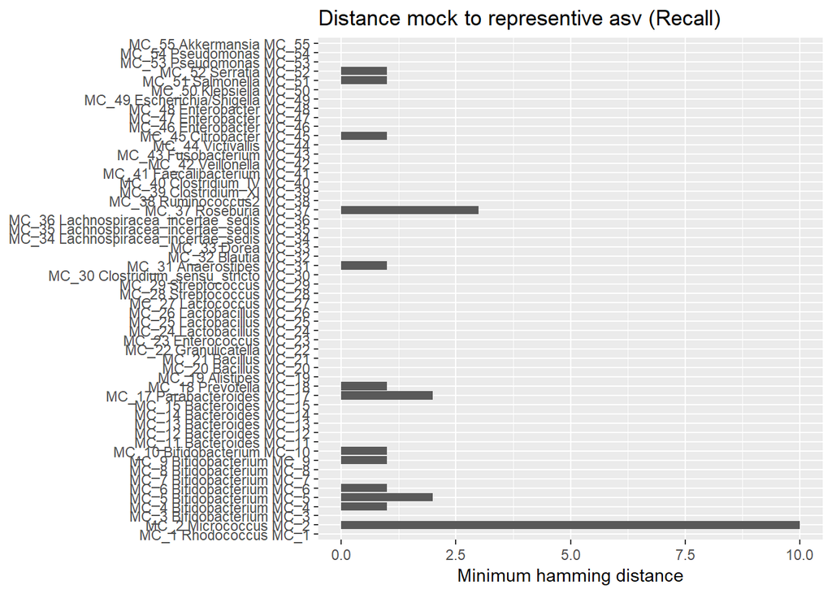

```r
#remove duplicated reference
mockref <- mockref[!duplicated(mockref)]


# get the hamming distance for each ASV and Mock member
# first build a dataframe
hamming.distance.mat <- matrix(nrow = length(asv.valid.seqs), ncol = length(mockref), NA)
colnames(hamming.distance.mat) <- mockref
rownames(hamming.distance.mat) <- asv.valid.seqs
hamming.distance.mat.long <- setNames(melt(hamming.distance.mat), c('asv', 'mock', 'dist'))

# calculate the hamming distance between all ASVs and the mock
hamming.distance.mat.long$dist <- nwhamming(as.character(hamming.distance.mat.long$asv),as.character(hamming.distance.mat.long$mock))

#Get the closest relative for each mock and asv
mockrefdist <- aggregate(dist ~ mock, data = hamming.distance.mat.long, min)
asvrefdist <- aggregate(dist ~ asv, data = hamming.distance.mat.long, min)
asvrefdist$name <- factor(paste0("ASV_",1:100), levels=paste0("ASV_",1:100))

mockrefdist$name <- factor(names(mockref)[match(mockref, mockrefdist$mock)], levels=names(mockref))
ggplot(mockrefdist, aes(x=name, y=dist)) +
  geom_bar(stat="identity") +
  coord_flip() +
  labs(y="Minimum hamming distance", title="Distance mock to representive asv (Recall)", x=NULL)
```

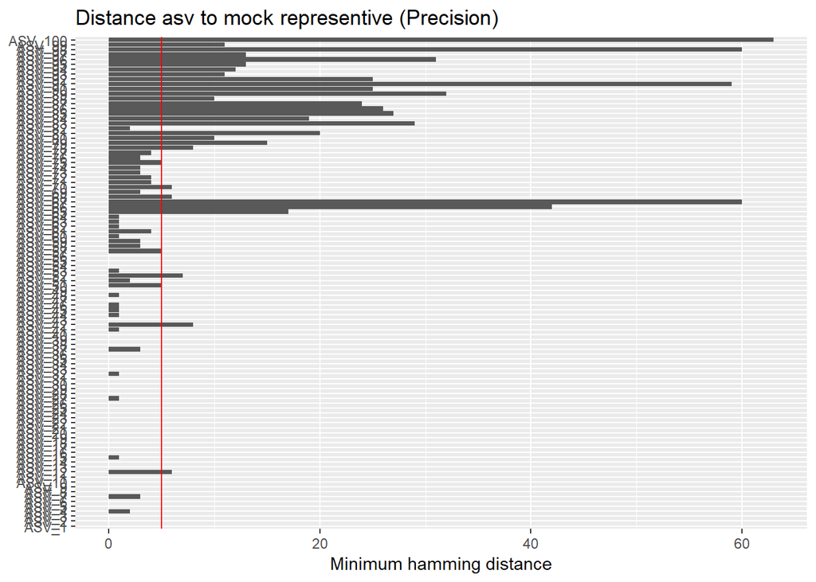

```r
ggplot(asvrefdist, aes(x=name, y=dist)) +
  geom_bar(stat="identity") +
  coord_flip() +
  ggplot2::geom_hline(yintercept = 5, col='red') +
  labs(y="Minimum hamming distance", title="Distance asv to mock representive (Precision)", x=NULL)
```

```r
# False positive ASVs
sum(asvrefdist$dist>=6)
```

```
## [1] 30
```

```r
# False positive ASVs total reads
sum(seqtab.nochim[asvrefdist$dist>=6])
```

```
## [1] 2083
```